# Outlier and Venn Diagram Results from Pinus contorta at different cutoffs for LFMM

Katie Lotterhos

April 28, 2015

Data used here is stored on hulk at /data/seqcap/pine/bwa_pseudo/round2_bams/bayenvResults20150416. It was transferred to klott@10.122.4.190:/Users/lotterke/Desktop/bayenvResults20150416 to make the markdown files

In this analysis, we ran lfmm (Frichot et al 2013) on over 200,000 SNPs from the Pine sequence capture. We had 22 environmental variables of biological interest.

### The SNP dataset

Here are the column names in the SNP dataset: (the ones named after the environments contain Bayes Factors from bayenv2 (Gunther and Coop 2013). “rho” represents Spearman’s rho also estimated from Bayenv 2, which indicates the correlation between the reference SNP frequency and the environment.) For the LFMM output (organized by Simon), columns are named envvar.z.lfmm.beagle for zscores (note that the abs(Zscore) should be used for calculating outliers) and envvar.q.lffm.beagle for q-values (I would not rely too much on q values).

```r
filename <- "../pine_data/bayenv.lfmmbeagle.res"
### read in file with log-BF
  if(!("f2" %in% ls())){
    f2<- read.table(filename, header=TRUE, comment.char="")
  }
  names(f2)
```

```
##   [1] "gcontig"                 "pos_gcontig"
##   [3] "X.annotation"            "paralogy_rank"
##   [5] "tcontig"                 "pos_tcontig"
##   [7] "gmap_percentID"          "offtarget_dist"
##   [9] "num_alleles"             "num_ind"
##  [11] "num_comm_gtype"          "major_allele"
##  [13] "major_num"               "major_freq"
##  [15] "minor_allele"            "minor_num"
##  [17] "minor_freq"              "freq_hetzyg"
##  [19] "MAP_dir1"                "MAP_dir2"
##  [21] "MAP_MgGm"                "noncode_in_covar"
##  [23] "MQ"                      "haplotype_score"
##  [25] "FS"                      "MQRankSum"
##  [27] "ReadPosRankSum"          "allele_balance"
##  [29] "window_stat"             "scaffold"
```

[output cut: 56 more lines]

```r
env <- read.table("../pine_data/sprucePineEnvi.clusters", header=TRUE)
env <- env[order(env$G4),]
```

The abs(z-scores) from all environments were pooled to calculate cutoffs for the different quartiles of the z-score distribution. Here are the cutoffs for those percentiles (calculated by Simon):

```r
### read in file with cutoffs
  cos <- read.table("../pine_data/zscore_cutoffs", header=TRUE)
  cos <- data.frame(-99, cos) #differs from Bayenv script
  names(cos)[1] <- "All"
  cos
```

```
##   All    V.90    V.95    V.99   V.999  V.9995  V.9999 V.99999
## 1 -99 2.26696 2.94238 4.70484 8.20377 9.18199 11.7786 15.6214
```

#### Now loop through some these cutoffs and summarize the results for environment enrichment:

### Results for V.9995 percentile, which corresponds to a abs(z) > 9.182 …

#### Total number of outliers (loci with abs(z) above threshold in any one environment): 1232

#### Venn diagrams of overlap among variables. Raw counts on left column, percentages on right column:

Note that the number in the bottom right corner of the Venn represents the number of SNPs that do not fit into any category and can be ignored.

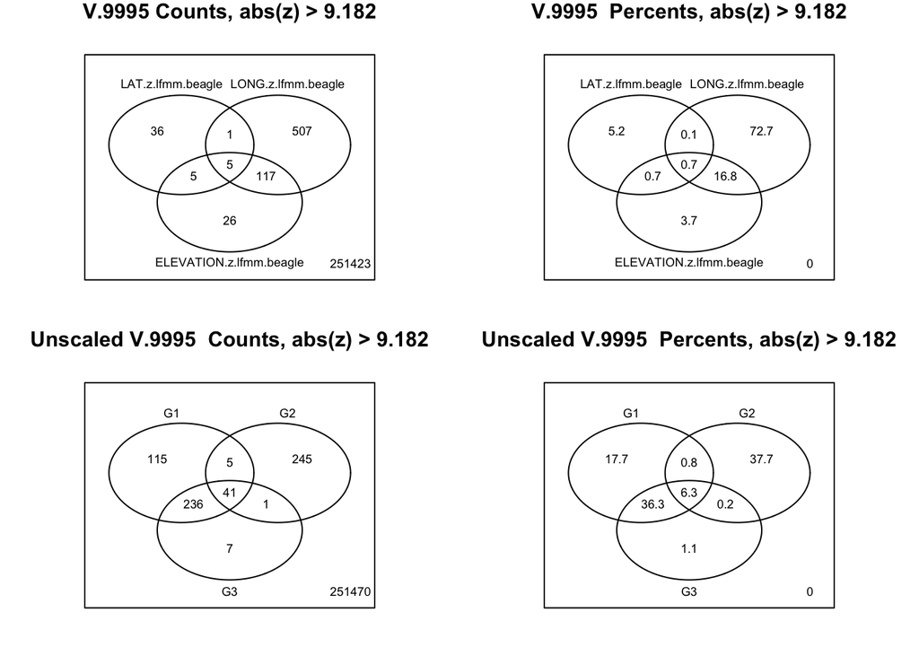

### Results for V.9999 percentile, which corresponds to a abs(z) > 11.779 …

#### Total number of outliers (loci with abs(z) above threshold in any one environment): 221

#### Venn diagrams of overlap among variables. Raw counts on left column, percentages on right column:

Note that the number in the bottom right corner of the Venn represents the number of SNPs that do not fit into any category and can be ignored.

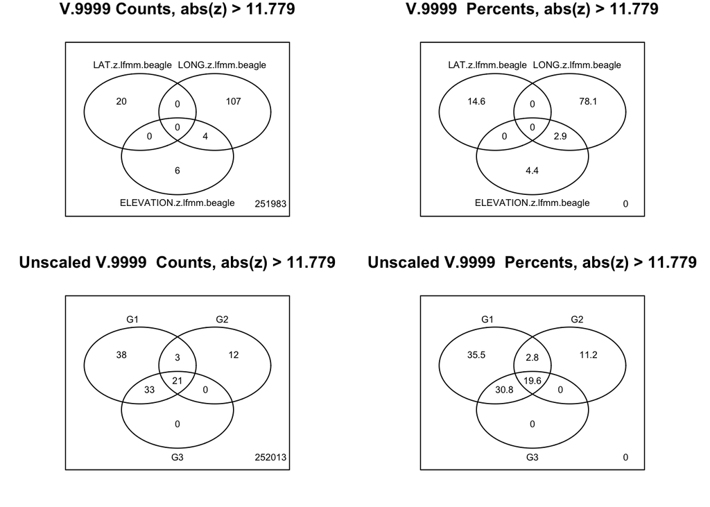

### Results for V.99999 percentile, which corresponds to a abs(z) > 15.621 …

#### Total number of outliers (loci with abs(z) above threshold in any one environment): 33

#### Venn diagrams of overlap among variables. Raw counts on left column, percentages on right column:

Note that the number in the bottom right corner of the Venn represents the number of SNPs that do not fit into any category and can be ignored.

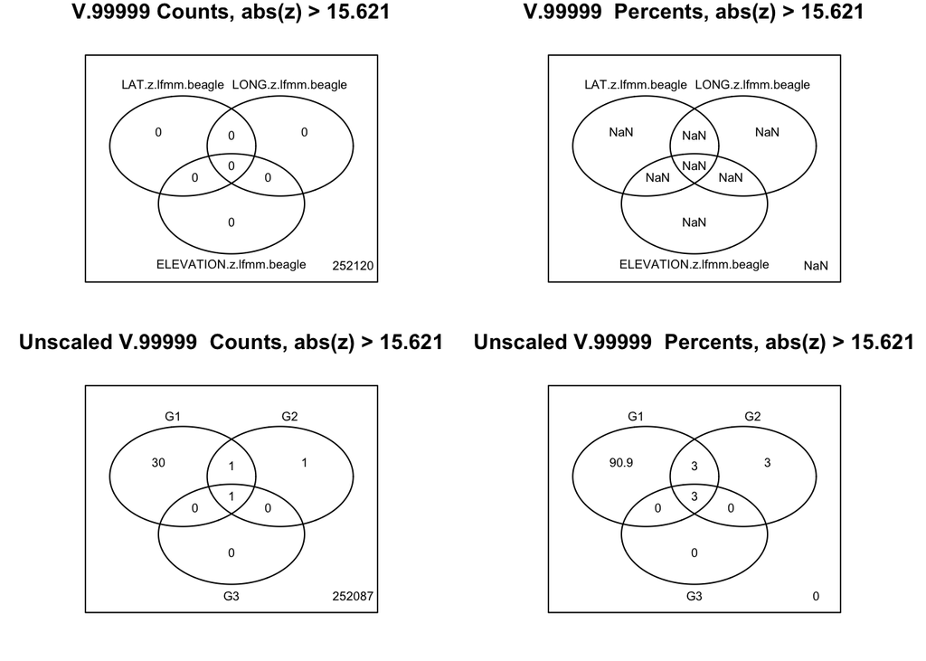

### Number of outliers based on different cutoffs

#### The number of outliers in each environmental variable

|  | enviAbb | enviDesc | numOutliers.All | numOutliers.V.99 | numOutliers.V.999 | numOutliers.V.9995 | numOutliers.V.9999 | numOutliers.V.99999 |
| --- | --- | --- | --- | --- | --- | --- | --- | --- |
| 1 | LAT | Latitude | 252120.00 | 3459.00 | 137.00 | 47.00 | 20.00 | 0.00 |
| 2 | LONG | Longitude | 252120.00 | 12328.00 | 1290.00 | 630.00 | 111.00 | 0.00 |
| 3 | ELEVATION | Elevation | 252120.00 | 4877.00 | 384.00 | 153.00 | 10.00 | 0.00 |
| 4 | MAT | Mean ann. temp | 252120.00 | 1955.00 | 209.00 | 87.00 | 52.00 | 11.00 |
| 6 | MCMT | Mean coldest month | 252120.00 | 3641.00 | 292.00 | 174.00 | 52.00 | 6.00 |
| 7 | TD | Temp difference | 252120.00 | 3424.00 | 228.00 | 96.00 | 35.00 | 0.00 |
| 12 | DD_0 | Days < 0C | 252120.00 | 2811.00 | 223.00 | 104.00 | 47.00 | 0.00 |
| 19 | EMT | Extreme min. temp 30 years | 252120.00 | 4742.00 | 502.00 | 353.00 | 81.00 | 32.00 |
| 8 | MAP | Mean annual precipitation | 252120.00 | 1998.00 | 137.00 | 53.00 | 19.00 | 3.00 |
| 9 | MSP | Mean summer precipitation | 252120.00 | 802.00 | 1.00 | 0.00 | 0.00 | 0.00 |
| 10 | AHM | Anuual heat:moisture index | 252120.00 | 771.00 | 375.00 | 156.00 | 0.00 | 0.00 |
| 11 | SHM | Summer heat:moisture index | 252120.00 | 765.00 | 20.00 | 1.00 | 0.00 | 0.00 |
| 18 | PAS | Precipitation as snow | 252120.00 | 120.00 | 2.00 | 2.00 | 0.00 | 0.00 |
| 20 | EXT | Extreme max. temp 30 years | 252120.00 | 897.00 | 24.00 | 20.00 | 0.00 | 0.00 |
| 21 | Eref | Evaporation | 252120.00 | 874.00 | 162.00 | 26.00 | 17.00 | 0.00 |
| 22 | CMD | Climate moisture deficit | 252120.00 | 902.00 | 413.00 | 206.00 | 0.00 | 0.00 |
| 5 | MWMT | Mean warmest month | 252120.00 | 183.00 | 14.00 | 0.00 | 0.00 | 0.00 |
| 13 | DD5 | Days > 5C | 252120.00 | 494.00 | 57.00 | 32.00 | 0.00 | 0.00 |
| 14 | NFFD | # frost-free days | 252120.00 | 3469.00 | 419.00 | 267.00 | 54.00 | 1.00 |
| 15 | bFFP | Begin frost-free period | 252120.00 | 1323.00 | 27.00 | 3.00 | 1.00 | 0.00 |
| 16 | eFFP | End frost-free period | 252120.00 | 3461.00 | 400.00 | 264.00 | 52.00 | 1.00 |
| 17 | FFP | Frost-free period | 252120.00 | 2161.00 | 228.00 | 98.00 | 3.00 | 1.00 |

#### The number of outliers for just Lat, Long, and Elevation

|  | Category | numOutliers.All | numOutliers.V.99 | numOutliers.V.999 | numOutliers.V.9995 | numOutliers.V.9999 | numOutliers.V.99999 |
| --- | --- | --- | --- | --- | --- | --- | --- |
| 1 | LAT.lfmm | 252120 | 3459 | 137 | 47 | 20 | 0 |
| 2 | LONG.lfmm | 252120 | 12328 | 1290 | 630 | 111 | 0 |
| 3 | ELEVATION.lfmm | 252120 | 4877 | 384 | 153 | 10 | 0 |

#### The number of outliers for the three environmental groups

|  | Category | numOutliers.All | numOutliers.V.99 | numOutliers.V.999 | numOutliers.V.9995 | numOutliers.V.9999 | numOutliers.V.99999 |
| --- | --- | --- | --- | --- | --- | --- | --- |
| 1 | Group 1 (temp) | 252120 | 6685 | 569 | 397 | 95 | 32 |
| 2 | Group 2 (precip) | 252120 | 2979 | 547 | 292 | 36 | 3 |
| 3 | Group 3 (frost-free) | 252120 | 3952 | 432 | 285 | 54 | 1 |

#### The number of outliers for the three environmental groups scaled by the number of variables in each group

Note that because of the scaling these are not whole numbers.

|  | Category | numOutliers.All | numOutliers.V.99 | numOutliers.V.999 | numOutliers.V.9995 | numOutliers.V.9999 | numOutliers.V.99999 |
| --- | --- | --- | --- | --- | --- | --- | --- |
| 1 | Group 1 (temp) scaled | 50424.00 | 1337.00 | 113.80 | 79.40 | 19.00 | 6.40 |
| 2 | Group 2 (precip) scaled | 31515.00 | 372.40 | 68.40 | 36.50 | 4.50 | 0.40 |
| 3 | Group 3 (frost-free) scaled | 42020.00 | 658.70 | 72.00 | 47.50 | 9.00 | 0.20 |

### Proportion of outliers based on different cutoffs

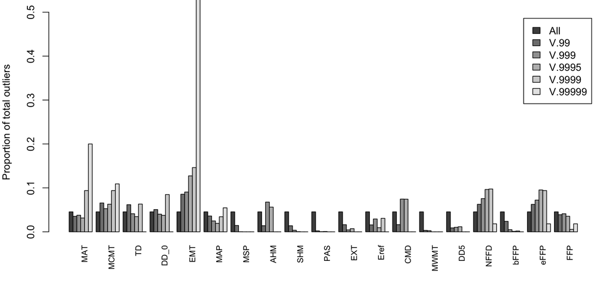

See the environmentSummary.html for information on the environments and their abbreviations. The x-axis is sorted according to groups. MAT to EMT is Group 1; MAP to CMD is Group 2, and MWMT to FFP is Group 3.

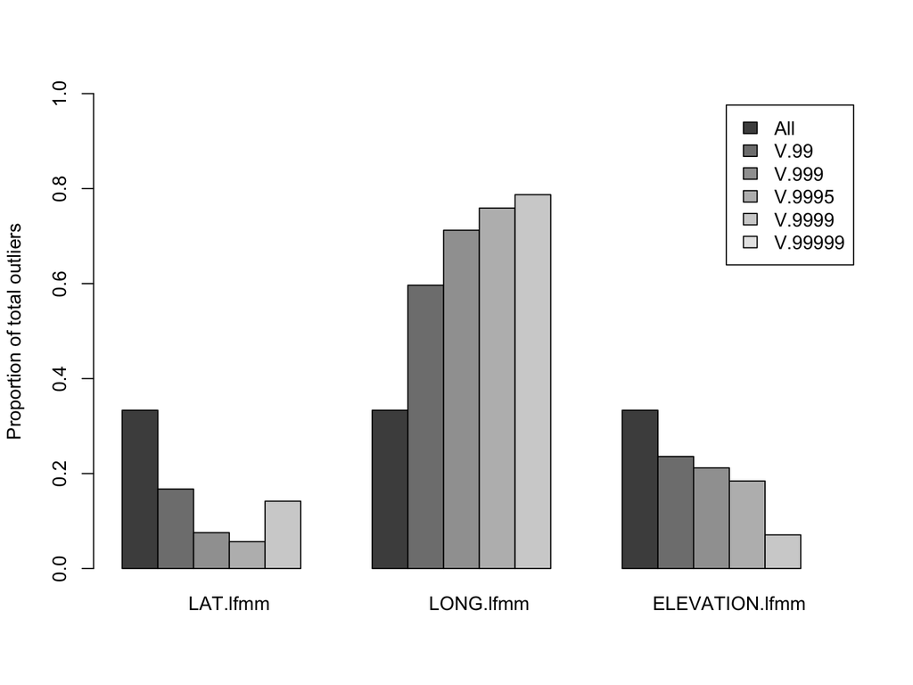

LFMM found a large number of loci with strong associations with Longitude relative to the other variables. These results differ from the Bayenv2 analysis, which found large number of loci with moderate assocations with longitude, and a smaller number of loci with very strong associations with latitude. When we look at these results in combination with the Venn diagrams above, we see there is very little overlap among outliers in these three categories.

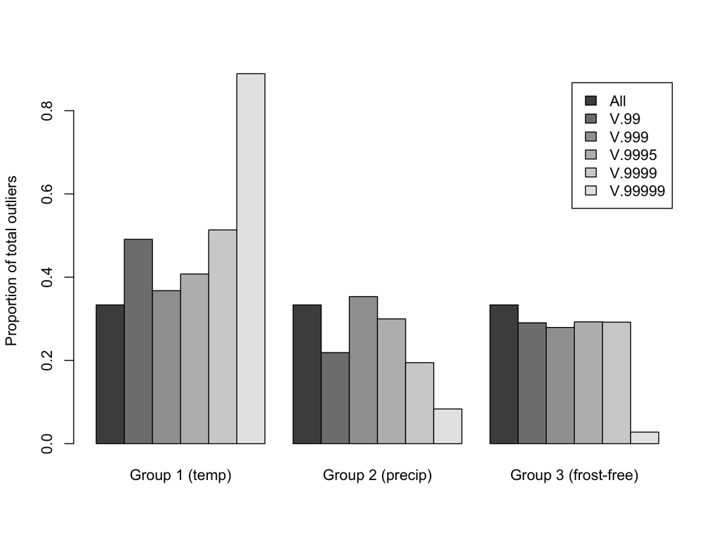

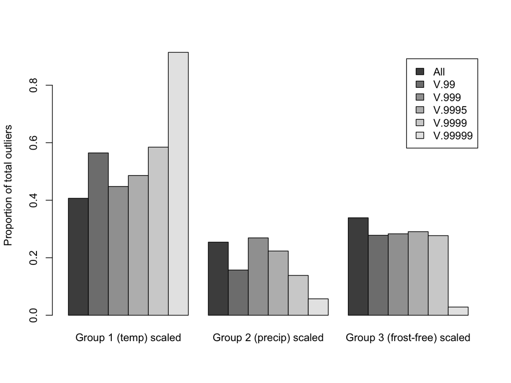

LFMM found very strong associations with Group 1 relative to the other groups. Bayenv also found enrichment for strong associations with group 1, but also a large number of loci with moderate assocations with Group 2. See environmentSummary.html for a summary of the three environmental groups.

These results can be broken down into the independent environmental variables (graphed above) to see which variables are driving this pattern. The large z-scores in group 1 are being driven by MAT (mean annual temp), MCMT (mean coldest month), DD_0 (days below 0C), and EMT (extreme minimum temp 30 years) — so it seems they are being driven by cold (note the exact same results in Bayenv2). Similar results from Bayenv2 were found for group 2: lfmm found moderate associations with MAP, AHM, and CMD (bayenv found moderate associations with AHM (Annual heat:moisture index), SHM (summer heat:moisture index), EREF (evaporation), and CMD (climate moisture deficit)). Outliers in Group 3 are from NFFD (number frost-free days) and eFFP (end frost-free period) (same as bayenv2).

These results seem consistent with the hypothesis that adaptation to temperature is driven mostly by minimum temperatures (but not the length of the freezing period, which is represented by group 3), and consists of relatively fewer loci that (i) may have larger effect sizes and/or (ii) may be acted on by stronger selection. Adaptation to moisture and precipitation consists of a relatively larger number of loci that (i) may have smaller effect sizes and/or (ii) may be acted on by weaker selection. These results are also consistent with adaptation to precipitation being associated with more complex traits.

#### Now loop through some these cutoffs and summarize the results for enrichment of different genomic categories:

There are two approaches toward looking at enrichment: based on annotation category, or based on the set of non-coding SNPs used in the covariance matrix.

##### Results based on annotation category

Here, for each locus I used the maximum abs(z_score) observed in any one environment. Then, I made a new annotation category that lumped together all non-synomymous SNPs. Next, I compared the proportion of SNPs in each annotation category for progressively more stringent cutoffs:

```r
  levels(f2$X.annotation)
```

```
##   [1] "3primeFLANK"     "3primeUTR"       "5primeFLANK"
##   [4] "5primeUTR"       "HAS_INDEL"       "intron"
##   [7] "mismatch_altref" "multi-allelic"   "non_tcontig"
##  [10] "nonsyn___to_C"   "nonsyn___to_E"   "nonsyn___to_G"
##  [13] "nonsyn___to_K"   "nonsyn___to_L"   "nonsyn___to_Q"
##  [16] "nonsyn___to_R"   "nonsyn___to_S"   "nonsyn___to_W"
##  [19] "nonsyn___to_Y"   "nonsyn_A_to_D"   "nonsyn_A_to_E"
##  [22] "nonsyn_A_to_G"   "nonsyn_A_to_P"   "nonsyn_A_to_S"
##  [25] "nonsyn_A_to_T"   "nonsyn_A_to_V"   "nonsyn_C_to__"
##  [28] "nonsyn_C_to_F"   "nonsyn_C_to_G"   "nonsyn_C_to_R"
##  [31] "nonsyn_C_to_S"   "nonsyn_C_to_W"   "nonsyn_C_to_Y"
##  [34] "nonsyn_D_to_A"   "nonsyn_D_to_E"   "nonsyn_D_to_G"
##  [37] "nonsyn_D_to_H"   "nonsyn_D_to_N"   "nonsyn_D_to_V"
##  [40] "nonsyn_D_to_Y"   "nonsyn_E_to__"   "nonsyn_E_to_A"
##  [43] "nonsyn_E_to_D"   "nonsyn_E_to_G"   "nonsyn_E_to_K"
```

[output cut: 46 more lines]

```r
### Make a new annotation category
    new.annot <- as.character(unlist(f2$X.annotation))
    new.annot[grep("nonsyn", f2$X.annotation)] <- "nonsyn"
    new.annot <- as.factor(new.annot)
    levels(new.annot)
```

```
##  [1] "3primeFLANK"     "3primeUTR"       "5primeFLANK"
##  [4] "5primeUTR"       "HAS_INDEL"       "intron"
##  [7] "mismatch_altref" "multi-allelic"   "non_tcontig"
## [10] "nonsyn"          "synonymous"      "unk_adj"
## [13] "unk_flank"       "UNKNOWN_ORF"
```

```
## [1] 15
## [1] 15
## [1] 15
## [1] 15
## [1] 15
```

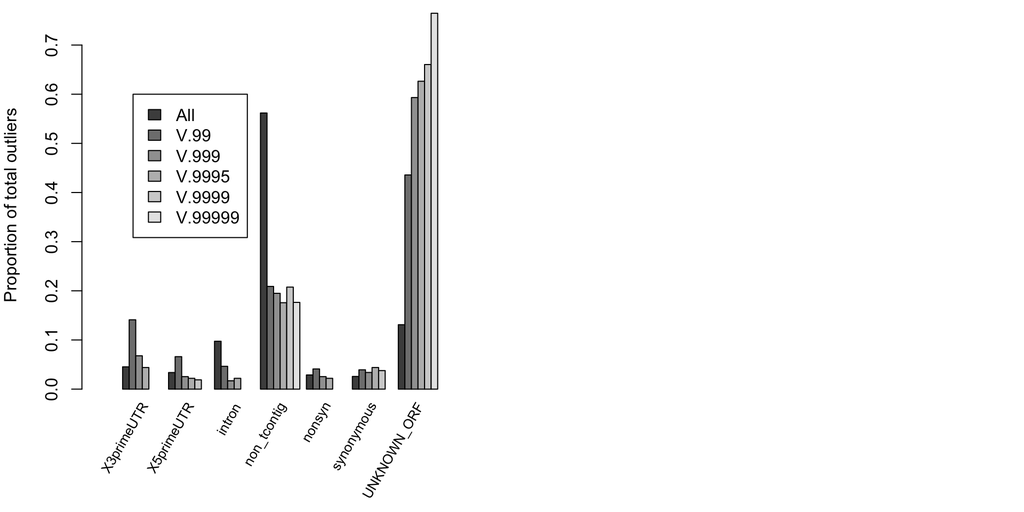

```r
### Calculate the max(abs(zscore)) for a locus across all environments
  if(!("max.BF" %in% ls())){  #note that this is really calculating z-scores and not BF
    #also note that for NA rows you will get a warning here
  max.BF <- apply(abs(f2[,colBF]), 1, max, na.rm=TRUE)
  max.BF[is.infinite(max.BF)]<-NA
  }

### functions to get proportions
get.prop.newannot <- function(V, ind, rowname=NULL){
  a<- tapply(V[ind], new.annot[ind], length)
  a2<- data.frame(t(a/sum(a, na.rm=TRUE)))
  rownames(a2) <- rowname
  a2
  }

### For barplot, x-axis categories are in columns and colored bars are in rows
  enrich.new.annot <- data.frame(cutoff="All", get.prop.newannot(max.BF, TRUE))

  cutoff2 <- as.numeric(cos[1, 4:8])
  cutoff2names <- names(cos[1, 4:8])
  for (i in 1:length(cutoff2)){
    n2 <- data.frame(cutoff=cutoff2names[i], get.prop.newannot(max.BF, max.BF>=cutoff2[i]) )
    print(length(n2))
    enrich.new.annot<- merge(enrich.new.annot, n2, all.x=TRUE, all.y=TRUE)
  }
```

#### Results based on proportion of noncoding SNPs used in covariance matrix

```r
levels(f2$noncode_in_covar)
```

```
## [1] "in_covar" "no"
```

```r
get.prop.noncod <- function(V, ind){
  a<- tapply(V[ind], f2$noncode_in_covar[ind], length)
  as.numeric((a/sum(a, na.rm=TRUE))[1])
  }

  enrich.noncod <- get.prop.noncod(max.BF, TRUE)
  for (i in 1:length(cutoff2)){
    enrich.noncod <- c(enrich.noncod, get.prop.noncod(max.BF, max.BF>=cutoff2[i]) )
  }
  names(enrich.noncod) <- c("All", cutoff2names)
  enrich.noncod
```

```
##         All        V.99       V.999      V.9995      V.9999     V.99999
## 0.007993228 0.010714286 0.016949153 0.010989011 0.018867925          NA
```

#### Histogram of BF from noncoding SNPs used in covmat vs. other SNPs

```r
 low <- min(max.BF, na.rm=TRUE)
 high <- max(max.BF, na.rm=TRUE)
levels(f2$noncode_in_covar)
```

```
## [1] "in_covar" "no"
```

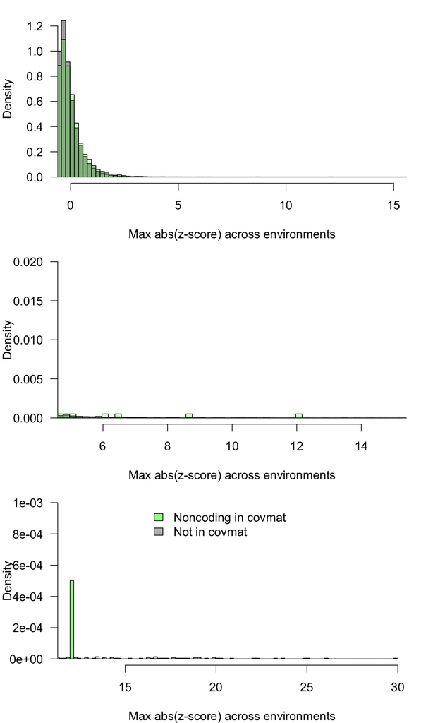

```r
#[1] "in_covar" "no"
#note x-axis on histograms are different
  br <- seq(low-0.2, high+0.2, by=0.2)
  par(mfcol=c(3,1), mar=c(4,4,1,1), cex=1.2, las=1)
  hist(max.BF[f2$noncode_in_covar=="no"], breaks=br, freq=FALSE, col="darkgrey", xlim=c(0,15), main="", xlab="Max abs(z-score) across environments")
  hist(max.BF[f2$noncode_in_covar=="in_covar"], breaks=br, freq=FALSE, add=TRUE, col=rgb(0,1,0,0.2))

  hist(max.BF[f2$noncode_in_covar=="no"], breaks=br, xlim=c(5, 15), freq=FALSE, ylim=c(0,0.02),  main="", xlab="Max abs(z-score) across environments", col="darkgrey")
  hist(max.BF[f2$noncode_in_covar=="in_covar"], breaks=br, freq=FALSE, add=TRUE, col=rgb(0,1,0,0.2))

  hist(max.BF[f2$noncode_in_covar=="no"], breaks=br, xlim=c(12, high), freq=FALSE, ylim=c(0,0.001),  main="", xlab="Max abs(z-score) across environments", col="grey")
  hist(max.BF[f2$noncode_in_covar=="in_covar"], breaks=br, freq=FALSE, add=TRUE, col=rgb(0,1,0,0.5))
  legend(16,0.001, c("Noncoding in covmat", "Not in covmat"), fill=c(rgb(0,1,0,0.5),"grey" ), bty="n")
```